**Homework Day 14**

**Author: Ahmad Ichsan Baihaqi**

**Email: ahmadichsanbaihaqi@gmail.com**

**Topic: EDA with R**

[Dataset](https://www.kaggle.com/c/house-prices-advanced-regression-techniques/data?select=train.csv).

For information, I use [this](https://rpubs.com/haritmm97/HousePrice) resource as reference for this challenge.

```r
library(ggplot2)
library(caret)
library(stringr)
library(tibble)
library(tidyr)
library(readr)
library(gplots)
library(repr)
library(rpart.plot)
library(patchwork)
library(scales)
library(reshape2)
library(plyr)
library(dplyr)
df = read.csv('train.csv')
```

```r
head(df)
```

```
##   Id MSSubClass MSZoning LotFrontage LotArea Street Alley LotShape LandContour
## 1  1         60       RL          65    8450   Pave  <NA>      Reg         Lvl
## 2  2         20       RL          80    9600   Pave  <NA>      Reg         Lvl
## 3  3         60       RL          68   11250   Pave  <NA>      IR1         Lvl
## 4  4         70       RL          60    9550   Pave  <NA>      IR1         Lvl
## 5  5         60       RL          84   14260   Pave  <NA>      IR1         Lvl
## 6  6         50       RL          85   14115   Pave  <NA>      IR1         Lvl
##   Utilities LotConfig LandSlope Neighborhood Condition1 Condition2 BldgType
## 1    AllPub    Inside       Gtl      CollgCr       Norm       Norm     1Fam
## 2    AllPub       FR2       Gtl      Veenker      Feedr       Norm     1Fam
## 3    AllPub    Inside       Gtl      CollgCr       Norm       Norm     1Fam
## 4    AllPub    Corner       Gtl      Crawfor       Norm       Norm     1Fam
## 5    AllPub       FR2       Gtl      NoRidge       Norm       Norm     1Fam
## 6    AllPub    Inside       Gtl      Mitchel       Norm       Norm     1Fam
##   HouseStyle OverallQual OverallCond YearBuilt YearRemodAdd RoofStyle RoofMatl
```

[output cut: 69 more lines]

Remove Id variable (not used)

```r
df = df %>% select(-c("Id"))
```

```r
head(df)
```

```
##   MSSubClass MSZoning LotFrontage LotArea Street Alley LotShape LandContour
## 1         60       RL          65    8450   Pave  <NA>      Reg         Lvl
## 2         20       RL          80    9600   Pave  <NA>      Reg         Lvl
## 3         60       RL          68   11250   Pave  <NA>      IR1         Lvl
## 4         70       RL          60    9550   Pave  <NA>      IR1         Lvl
## 5         60       RL          84   14260   Pave  <NA>      IR1         Lvl
## 6         50       RL          85   14115   Pave  <NA>      IR1         Lvl
##   Utilities LotConfig LandSlope Neighborhood Condition1 Condition2 BldgType
## 1    AllPub    Inside       Gtl      CollgCr       Norm       Norm     1Fam
## 2    AllPub       FR2       Gtl      Veenker      Feedr       Norm     1Fam
## 3    AllPub    Inside       Gtl      CollgCr       Norm       Norm     1Fam
## 4    AllPub    Corner       Gtl      Crawfor       Norm       Norm     1Fam
## 5    AllPub       FR2       Gtl      NoRidge       Norm       Norm     1Fam
## 6    AllPub    Inside       Gtl      Mitchel       Norm       Norm     1Fam
##   HouseStyle OverallQual OverallCond YearBuilt YearRemodAdd RoofStyle RoofMatl
```

[output cut: 69 more lines]

# 1. Start with the target

**Question**:

Do univariate analysis on target variable, SalePrice, and explain insight that you got.

**Answer**:

Intro: SalePrice is a feature which represents the property’s sale price in dollars.

```r
target_variable = df$SalePrice
```

*1. Check if there is any missing value*

```r
target_variable %>% is.na() %>% sum()
```

```
## [1] 0
```

Information based on above process:

1. No missing value found in SalePrice variable

*2. Get summary of the data*

```r
summary(target_variable)
```

```
##    Min. 1st Qu.  Median    Mean 3rd Qu.    Max.
##   34900  129975  163000  180921  214000  755000
```

Information based on above summary:

1. Mean value is a little far from the median. This indicate that there are SalePrice with high value which could be an outlier in our dataset.
2. Max value, which 755000, is too far from the median and 3rd Quartile. This information can support our interpretation on point 1.

*3. Data Visualization*

We can use histogram to see our SalePrice data distribution.

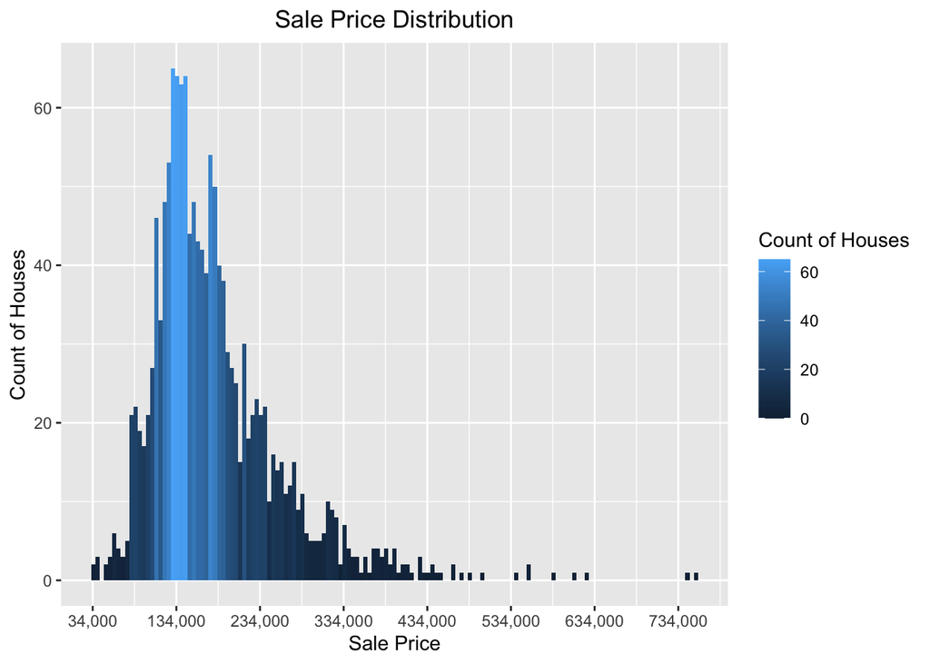

```r
options(scipen=10000)
ggplot(df, aes(x = SalePrice, fill = ..count..)) +
  geom_histogram(binwidth = 5000) +
  ggtitle('Sale Price Distribution') +
  ylab("Count of Houses") +
  xlab("Sale Price") +
  scale_x_continuous(labels = comma, breaks = seq(34000, 760000, by = 100000)) +
  theme(plot.title = element_text(hjust = 0.5)) +
  labs(fill = "Count of Houses")
```

Information based on histogram visualization:

1. Sale Price dataset is positively skewed. We could see several points appear outside the majority of the distribution. Later we could see with boxplot to see the outliers.
2. Count of houses raised with Sale Price between (approx) 84,000 and (approx) 184,000

We can use boxplot to see SalePrice data distribution and find the outliers.

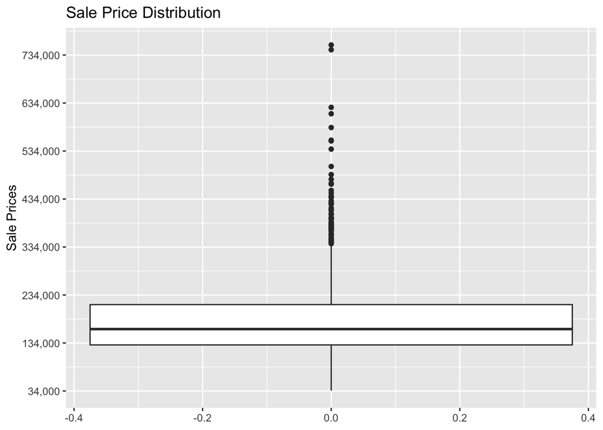

```r
ggplot(df, aes(y = SalePrice)) +
  geom_boxplot() +
  ggtitle('Sale Price Distribution') +
  ylab('Sale Prices') +
  scale_y_continuous(labels = comma, breaks = seq(34000, 760000, by = 100000))
```

Information based on boxplot visualization:

1. There are a lot of outliers. But, we can’t jump to conclusion that the outliers is not importants. This is because SalePrice values is affected by other variables which not displayed here.

# 2. SalePrice correlation

**Question**:

Find 5 variables with high correlation (positive and negative) on SalePrice. Determined if the results is make sense?

**Answer**:

To find correlation between variables and our target, we could use Correlation Heatmap to plot correlation coefficients. But, to build a heatmap, the variables should be in numeric. Let’s find out the structure of our data first.

Get structure of our data

```r
str(df)
```

```
## 'data.frame':    1460 obs. of  80 variables:
##  $ MSSubClass   : int  60 20 60 70 60 50 20 60 50 190 ...
##  $ MSZoning     : chr  "RL" "RL" "RL" "RL" ...
##  $ LotFrontage  : int  65 80 68 60 84 85 75 NA 51 50 ...
##  $ LotArea      : int  8450 9600 11250 9550 14260 14115 10084 10382 6120 7420 ...
##  $ Street       : chr  "Pave" "Pave" "Pave" "Pave" ...
##  $ Alley        : chr  NA NA NA NA ...
##  $ LotShape     : chr  "Reg" "Reg" "IR1" "IR1" ...
##  $ LandContour  : chr  "Lvl" "Lvl" "Lvl" "Lvl" ...
##  $ Utilities    : chr  "AllPub" "AllPub" "AllPub" "AllPub" ...
##  $ LotConfig    : chr  "Inside" "FR2" "Inside" "Corner" ...
##  $ LandSlope    : chr  "Gtl" "Gtl" "Gtl" "Gtl" ...
##  $ Neighborhood : chr  "CollgCr" "Veenker" "CollgCr" "Crawfor" ...
##  $ Condition1   : chr  "Norm" "Feedr" "Norm" "Norm" ...
##  $ Condition2   : chr  "Norm" "Norm" "Norm" "Norm" ...
```

[output cut: 66 more lines]

```r
table(sapply(df, class))
```

```
##
## character   integer
##        43        37
```

As we can see above, there are 43 variables with characters type and 37 variables with integer types. There are a lot of variable to be encoded from categorical into numeric. To limit our challenge, assumed that variable which has missing value has no correlation with the SalePrice.

Find missing value

```r
find_missing_value = sapply(df, function(x) sum(is.na(x)))

column_with_missing_value = find_missing_value[find_missing_value > 0]

column_with_missing_value
```

```
##  LotFrontage        Alley   MasVnrType   MasVnrArea     BsmtQual     BsmtCond
##          259         1369            8            8           37           37
## BsmtExposure BsmtFinType1 BsmtFinType2   Electrical  FireplaceQu   GarageType
##           38           37           38            1          690           81
##  GarageYrBlt GarageFinish   GarageQual   GarageCond       PoolQC        Fence
##           81           81           81           81         1453         1179
##  MiscFeature
##         1406
```

Btw, above information is quite interestiong. All variable which related with “Garage” has same total missing value. I assumed that this is because the house didn’t have a garage. Let’s see how much house with no garage.

```r
sum(df$GarageArea == 0)
```

```
## [1] 81
```

Okay, that’s confirmed our assumption.

Back to our topic, we won’t use those variable with missing value, let’s create a new dataframe without those variable.

```r
names(column_with_missing_value)
```

```
##  [1] "LotFrontage"  "Alley"        "MasVnrType"   "MasVnrArea"   "BsmtQual"
##  [6] "BsmtCond"     "BsmtExposure" "BsmtFinType1" "BsmtFinType2" "Electrical"
## [11] "FireplaceQu"  "GarageType"   "GarageYrBlt"  "GarageFinish" "GarageQual"
## [16] "GarageCond"   "PoolQC"       "Fence"        "MiscFeature"
```

```r
df_no_missing = df %>% select(-names(column_with_missing_value))

# double check
sapply(df_no_missing, function(x) sum(is.na(x)))
```

```
##    MSSubClass      MSZoning       LotArea        Street      LotShape
##             0             0             0             0             0
##   LandContour     Utilities     LotConfig     LandSlope  Neighborhood
##             0             0             0             0             0
##    Condition1    Condition2      BldgType    HouseStyle   OverallQual
##             0             0             0             0             0
##   OverallCond     YearBuilt  YearRemodAdd     RoofStyle      RoofMatl
##             0             0             0             0             0
##   Exterior1st   Exterior2nd     ExterQual     ExterCond    Foundation
##             0             0             0             0             0
##    BsmtFinSF1    BsmtFinSF2     BsmtUnfSF   TotalBsmtSF       Heating
##             0             0             0             0             0
##     HeatingQC    CentralAir     X1stFlrSF     X2ndFlrSF  LowQualFinSF
##             0             0             0             0             0
##     GrLivArea  BsmtFullBath  BsmtHalfBath      FullBath      HalfBath
##             0             0             0             0             0
##  BedroomAbvGr  KitchenAbvGr   KitchenQual  TotRmsAbvGrd    Functional
##             0             0             0             0             0
##    Fireplaces    GarageCars    GarageArea    PavedDrive    WoodDeckSF
##             0             0             0             0             0
##   OpenPorchSF EnclosedPorch    X3SsnPorch   ScreenPorch      PoolArea
##             0             0             0             0             0
##       MiscVal        MoSold        YrSold      SaleType SaleCondition
##             0             0             0             0             0
##     SalePrice
##             0
```

```r
str(df_no_missing)
```

```
## 'data.frame':    1460 obs. of  61 variables:
##  $ MSSubClass   : int  60 20 60 70 60 50 20 60 50 190 ...
##  $ MSZoning     : chr  "RL" "RL" "RL" "RL" ...
##  $ LotArea      : int  8450 9600 11250 9550 14260 14115 10084 10382 6120 7420 ...
##  $ Street       : chr  "Pave" "Pave" "Pave" "Pave" ...
##  $ LotShape     : chr  "Reg" "Reg" "IR1" "IR1" ...
##  $ LandContour  : chr  "Lvl" "Lvl" "Lvl" "Lvl" ...
##  $ Utilities    : chr  "AllPub" "AllPub" "AllPub" "AllPub" ...
##  $ LotConfig    : chr  "Inside" "FR2" "Inside" "Corner" ...
##  $ LandSlope    : chr  "Gtl" "Gtl" "Gtl" "Gtl" ...
##  $ Neighborhood : chr  "CollgCr" "Veenker" "CollgCr" "Crawfor" ...
##  $ Condition1   : chr  "Norm" "Feedr" "Norm" "Norm" ...
##  $ Condition2   : chr  "Norm" "Norm" "Norm" "Norm" ...
##  $ BldgType     : chr  "1Fam" "1Fam" "1Fam" "1Fam" ...
##  $ HouseStyle   : chr  "2Story" "1Story" "2Story" "2Story" ...
```

[output cut: 47 more lines]

Find categorical variable to be encoded

```r
character_variable = df_no_missing %>% select(where(is.character)) %>% names()

character_variable
```

```
##  [1] "MSZoning"      "Street"        "LotShape"      "LandContour"
##  [5] "Utilities"     "LotConfig"     "LandSlope"     "Neighborhood"
##  [9] "Condition1"    "Condition2"    "BldgType"      "HouseStyle"
## [13] "RoofStyle"     "RoofMatl"      "Exterior1st"   "Exterior2nd"
## [17] "ExterQual"     "ExterCond"     "Foundation"    "Heating"
## [21] "HeatingQC"     "CentralAir"    "KitchenQual"   "Functional"
## [25] "PavedDrive"    "SaleType"      "SaleCondition"
```

Encode all categorical variable

```r
label_encoder = function(vec){
    levels = sort(unique(vec))
    function(x){
        match(x, levels)
    }
}

encoded_no_missing = df_no_missing

for (column in character_variable) {
  encoded_no_missing[[column]] = label_encoder(df_no_missing[[column]])(df_no_missing[[column]])
}

head(encoded_no_missing)
```

```
##   MSSubClass MSZoning LotArea Street LotShape LandContour Utilities LotConfig
## 1         60        4    8450      2        4           4         1         5
## 2         20        4    9600      2        4           4         1         3
## 3         60        4   11250      2        1           4         1         5
## 4         70        4    9550      2        1           4         1         1
## 5         60        4   14260      2        1           4         1         3
## 6         50        4   14115      2        1           4         1         5
##   LandSlope Neighborhood Condition1 Condition2 BldgType HouseStyle OverallQual
## 1         1            6          3          3        1          6           7
## 2         1           25          2          3        1          3           6
## 3         1            6          3          3        1          6           7
## 4         1            7          3          3        1          6           7
## 5         1           14          3          3        1          6           8
## 6         1           12          3          3        1          1           5
##   OverallCond YearBuilt YearRemodAdd RoofStyle RoofMatl Exterior1st Exterior2nd
```

[output cut: 48 more lines]

```r
model_var <- c('SalePrice',
                'OverallQual','OverallCond','YearBuilt',
                'TotalBsmtSF',
                'GrLivArea','BedroomAbvGr','KitchenAbvGr',
                'TotRmsAbvGrd','Fireplaces',
                'GarageArea','OpenPorchSF','PoolArea',
                 'MSZoning', 'BldgType')

heat <- encoded_no_missing[,model_var]
```

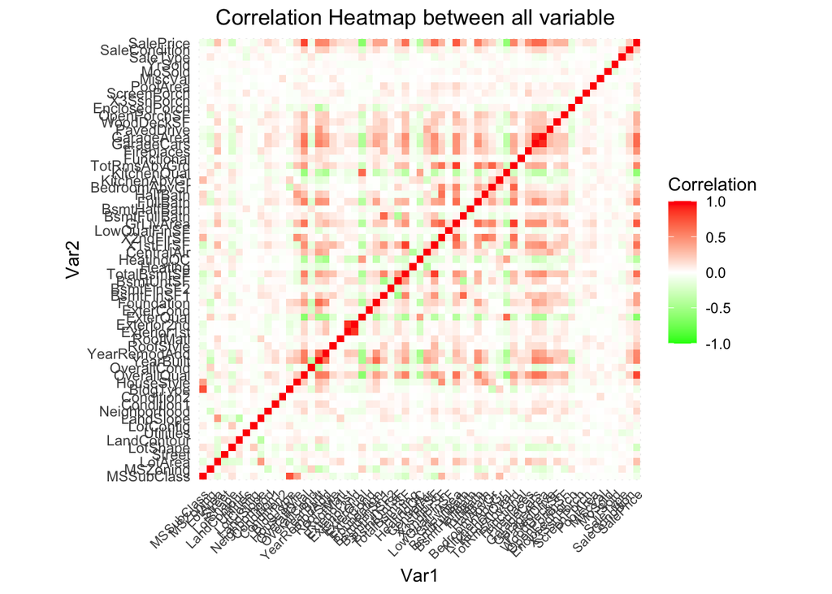

```r
options(repr.plot.width = 20, repr.plot.height = 20)
qplot(x=Var1, y=Var2, data=melt(cor(encoded_no_missing, use="p")), fill=value, geom="tile") +
   scale_fill_gradient2(low = "green", high = "red", mid = "white",
   midpoint = 0, limit = c(-1,1), space = "Lab",
   name="Correlation") +
   theme_minimal()+
   theme(axis.text.x = element_text(angle = 45, vjust = 1, size = 8, hjust = 1))+
   coord_fixed()+
   ggtitle("Correlation Heatmap between all variable") +
   theme(plot.title = element_text(hjust = 0.4))
```

Oops, looks like it’s too much. Let’s reduced the column XD

```r
model_var <- c('SalePrice',
                'OverallQual','OverallCond','YearBuilt',
                'TotalBsmtSF',
                'GrLivArea','BedroomAbvGr','KitchenAbvGr',
                'TotRmsAbvGrd','Fireplaces',
                'GarageArea','OpenPorchSF','PoolArea',
                 'MSZoning', 'BldgType')

heat <- encoded_no_missing[,model_var]
head(heat)
```

```
##   SalePrice OverallQual OverallCond YearBuilt TotalBsmtSF GrLivArea
## 1    208500           7           5      2003         856      1710
## 2    181500           6           8      1976        1262      1262
## 3    223500           7           5      2001         920      1786
## 4    140000           7           5      1915         756      1717
## 5    250000           8           5      2000        1145      2198
## 6    143000           5           5      1993         796      1362
##   BedroomAbvGr KitchenAbvGr TotRmsAbvGrd Fireplaces GarageArea OpenPorchSF
## 1            3            1            8          0        548          61
## 2            3            1            6          1        460           0
## 3            3            1            6          1        608          42
## 4            3            1            7          1        642          35
## 5            4            1            9          1        836          84
## 6            1            1            5          0        480          30
##   PoolArea MSZoning BldgType
## 1        0        4        1
## 2        0        4        1
## 3        0        4        1
## 4        0        4        1
## 5        0        4        1
## 6        0        4        1
```

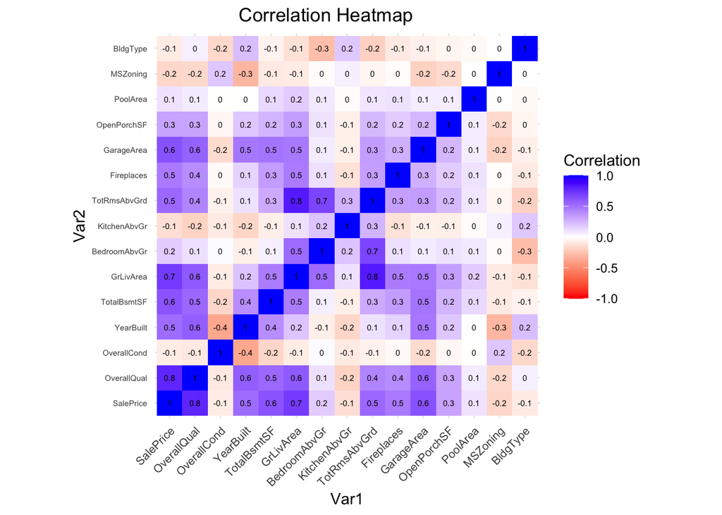

```r
geom.text.size = 2
theme.size = (14/5) * geom.text.size

ggplot(
      melt(cor(heat, use="p")),
      aes(
        x = Var1,
        y = Var2,
        fill = value,
      )
    ) +
    geom_tile() +
    scale_fill_gradient2(low = "red", high = "blue", mid = "white",
    midpoint = 0, limit = c(-1,1), space = "Lab",
    name="Correlation") +
    theme_minimal() +
    theme(axis.text.x = element_text(angle = 45, vjust = 1, size = 8, hjust = 1)) +
    ggtitle("Correlation Heatmap") +
    geom_text(
      aes(label = round(value, 1)),
      size=geom.text.size
    ) +
    theme(
      plot.title = element_text(hjust = 0.4),
      axis.text = element_text(size = theme.size)
    ) +
    coord_fixed()
```

Lol, I just realized that there is an example for corrplot in the class hands on :”

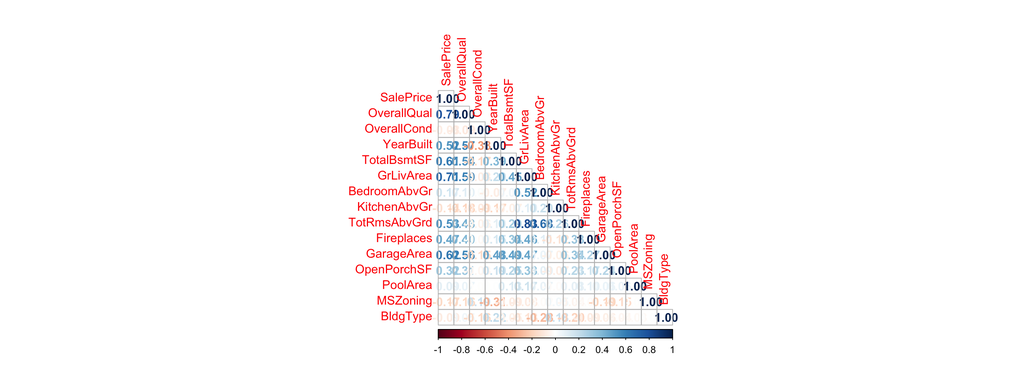

```r
heat %>% select_if(is.numeric) %>% cor() %>% corrplot::corrplot(type='lower',method = 'number')
```

Highest (five) correlation with SalePrice:

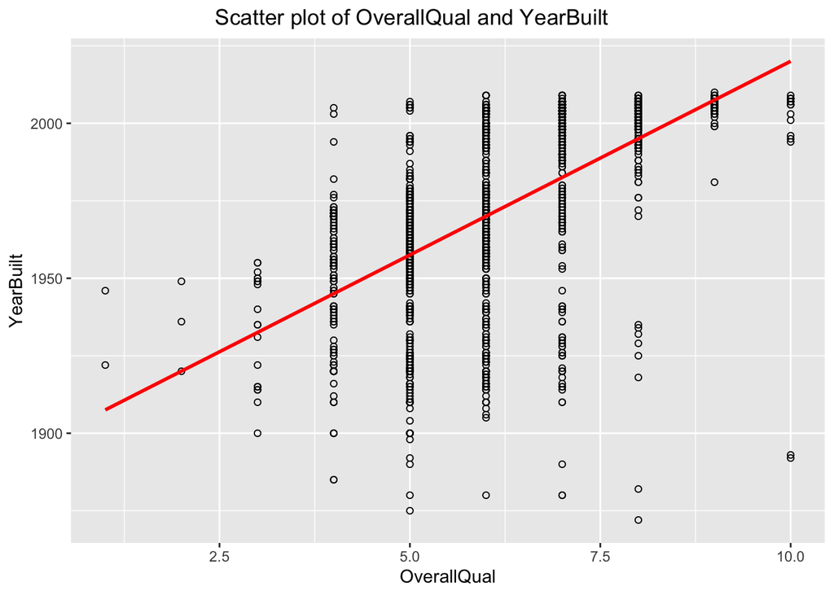

```r
ggplot(heat, aes(x=OverallQual, y=YearBuilt)) +
  geom_point(shape=1) +
  geom_smooth(method=lm , color="red", se=FALSE)+
  ggtitle("Scatter plot of OverallQual and YearBuilt") +
  theme(plot.title = element_text(hjust = 0.4))
```

Lowest (five) correlation with SalePrice:

1. MSZoning (-0.2) => MSZoning indicate the general zoning classification. The correlation value is the lowest, which indicate that MSZoning won’t affect the SalePrice. But, are you sure? Let’s visualize using boxplot between SalePrice and MSZoning

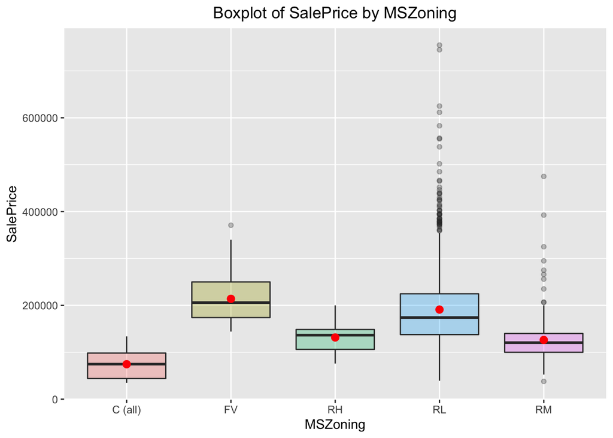

```r
options(repr.plot.width=9, repr.plot.height=6)
# boxplot of SalePrice by MSZoning
# add average value of SalePrice as red point
ggplot(df, aes(x=MSZoning, y=SalePrice, fill=MSZoning)) +
  geom_boxplot(alpha=0.3) +
  stat_summary(fun.y=mean, geom="point", shape=20, size=4, color="red", fill="red")+
  theme(legend.position="none")+
  ggtitle("Boxplot of SalePrice by MSZoning")+
  theme(plot.title = element_text(hjust = 0.5))
```

For information:

1. C (all) means commercial
2. FV means Floating Village Residential
3. RH means Residential High Density
4. RL means Residential Low Density
5. RM means Residential Medium Density

As we can see above, it clearly show us that there is a high SalePrice for RL (“Residential Low Density”) houses. Which means, MSZoning contribute for the SalePrice. Moreover, The sales in FV (“Floating Village Residential”) area have the highest average sale price, followed by RL (“Residential Low Density”). While C (all) (“Commercial”) sales have the lowest average sale price.

It is quite strange that commercial area has the lowest average Sale Price while village area has the highest. One possible explanation could be SalePrice is also related to the size of houses. To confirm, let’s explore the average size in these area.

The variable indicates size in this dataset is called GrLivArea.

```r
ddply(df, .(MSZoning), summarize,  size=mean(GrLivArea))
```

```
##   MSZoning     size
## 1  C (all) 1191.400
## 2       FV 1574.538
## 3       RH 1510.125
## 4       RL 1551.646
## 5       RM 1322.073
```

It is obvious that the avarage size of houses in Commecial are is much smaller than Floating Village area, which verified our assumption above.

In short, despite MSZoning has low correlation, MSZoning contribute to SalePrice due to each MSZoning has different GrLivArea mean which will affect the SalePrice.

2. OverallCond (-0.1) => OverallCond indicate the rates of the overall condition of the house.

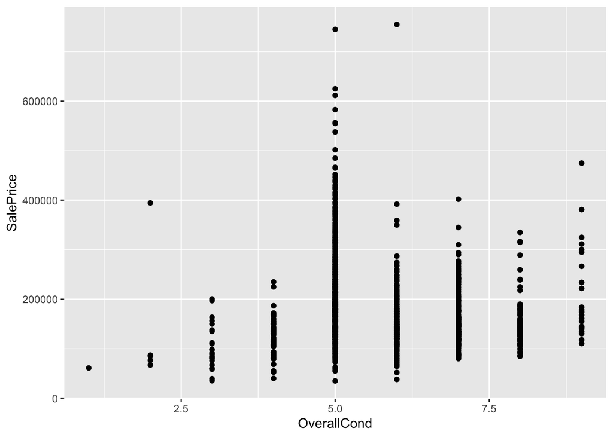

```r
df %>% ggplot(aes(x=OverallCond,y=SalePrice)) + geom_point()
```

Based on above visualization, it’s show us that OverallCond has low correlation with SalePrice. I couldn’t find how the OverallCond value determined, but I assumed that OverallCond is a “rate result” based on a lot of variable, which there are variable affect the SalePrice but some others is not, thus it will affect the OverallCond value but the OverallCond value itself is not directly related with SalePrice.

3. KitchenAbvGr (-0.1) => Idk why this feature exist in the dataset but has no description in data description on kaggle.
4. BldgType (-0.1) => BldgType indicate type of dwelling.

```r
unique(df$BldgType)
```

```
## [1] "1Fam"   "2fmCon" "Duplex" "TwnhsE" "Twnhs"
```

Unique value of BldgType:

1. 1Fam means Single-family Detached
2. 2FmCon means Two-family Conversion; originally built as one-family dwelling
3. Duplex
4. TwnhsE means Townhouse End Unit
5. Twnhs means Townhouse Inside Unit (in kaggle, it should be TwnhsI)

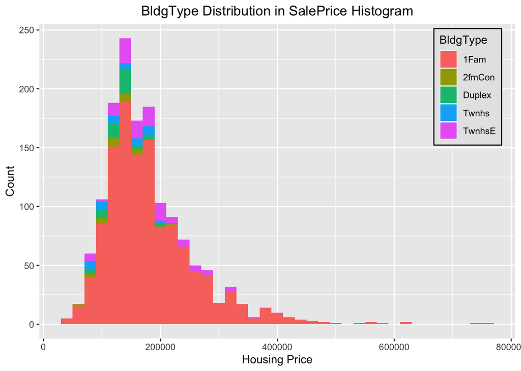

```r
# historgram of housing price by BldgType
ggplot(df, aes(SalePrice)) +
  geom_histogram(
    aes(fill = BldgType),
    position = position_stack(reverse = TRUE),
    binwidth = 20000
  ) +
  ggtitle("BldgType Distribution in SalePrice Histogram") +
  ylab("Count") +
  xlab("Housing Price") +
  theme(
    plot.title = element_text(hjust = 0.5),
    legend.position=c(0.9,0.8),
    legend.background = element_rect(fill = "grey90", size = 0.5, linetype = "solid", colour = "black")
  )
```

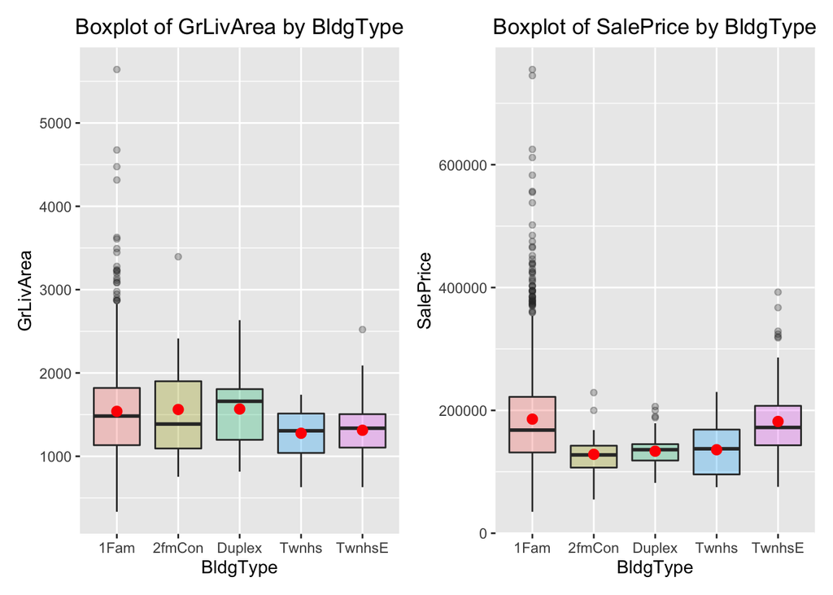

```r
options(repr.plot.width=9, repr.plot.height=6)
p1 = ggplot(df, aes(x=BldgType, y=GrLivArea, fill=BldgType)) +
  geom_boxplot(alpha=0.3) +
  stat_summary(fun=mean, geom="point", shape=20, size=4, color="red", fill="red")+
  theme(legend.position="none")+
  ggtitle("Boxplot of GrLivArea by BldgType")+
  theme(plot.title = element_text(hjust = 0.5))

p2 = ggplot(df, aes(x=BldgType, y=SalePrice, fill=BldgType)) +
  geom_boxplot(alpha=0.3) +
  stat_summary(fun=mean, geom="point", shape=20, size=4, color="red", fill="red")+
  theme(legend.position="none")+
  ggtitle("Boxplot of SalePrice by BldgType")+
  theme(plot.title = element_text(hjust = 0.5))

(p1 | p2)
```

Based on BldgType and SalePrice coefficient correlation, it shows a low correlation. At first, I assumed different BldgType will have a decent GrLivArea which will affect the SalePrice. But, based on above visualization, Duplex - which has highest GrLivArea mean - has a low price. As previous explanation, SalePrice is has high correlation with GrLivArea. *Which means, Duplex, with high GrLivArea, should has a high price. But, on the right boxplot, it shows that Duplex has low price*. Then, why Duplex has low SalePrice? I assumed, that the price also affected by the demand. High demand, limited supplies, will raised the sale price. In this case, Duplex has low demand despite it’s high GrLivArea. Thats why Duplex has low price.

5. PoolArea (0.1) => Indicate size of pool area in square feet. It’s show a positive correlation. Which means, pool affect the sale price. But, since pool is not a mandatory feature of a house, the correlation is not high.

# 3. It is never hurt to test basic knowledge.

**Question**:

Ada pandangan bahwa OverallQual rendah memiliki kecenderungan harga yang lebih rendah, dan rumah dengan OverallQual tinggi memiliki kecenderungan harga yang lebih tinggi. Lakukan analisis terhaadp hubungan OverallQual dan SalePrice.

**Answer**:

OverallQual variable means the overall material and finish quality. House with higher quality tend to have a high price. On the other hand, house with lower quality tend to have lower price.

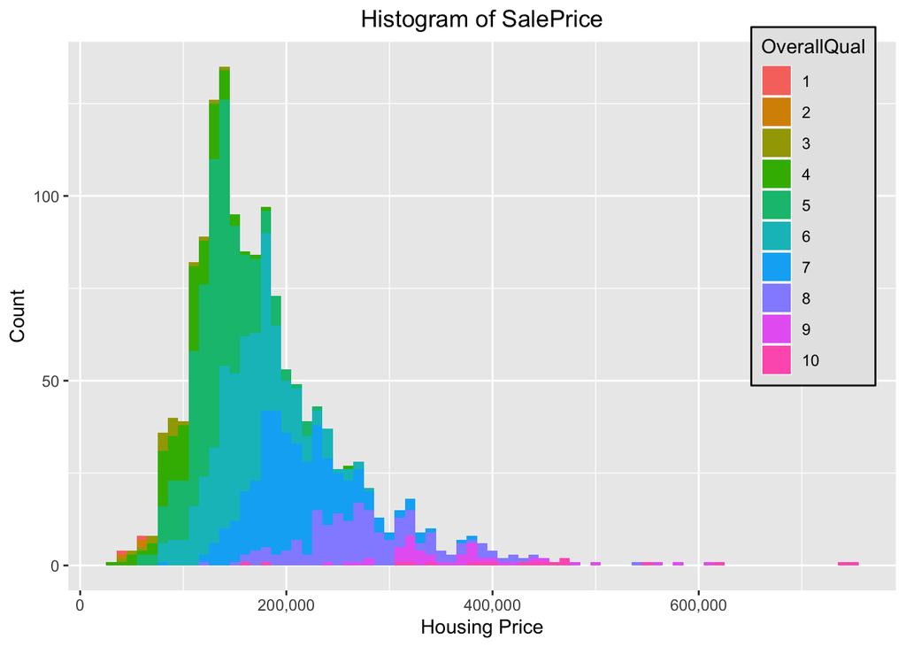

```r
ggplot(df, aes(x = SalePrice,fill = as.factor(OverallQual))) +
  geom_histogram(position = "stack", binwidth = 10000) +
  ggtitle("Histogram of SalePrice") +
  ylab("Count") +
  xlab("Housing Price") +
  scale_fill_discrete(name="OverallQual")+
  theme(
    plot.title = element_text(hjust = 0.5),
    legend.position=c(0.9,0.7),
    legend.background = element_rect(fill="grey90", size=0.5, linetype="solid",  colour ="black")
  ) +
  scale_x_continuous(labels = comma)
```

Based on above visualization, we can see that most of high OverallQual value lies above 300,000 while lower OverallQual mostly lies below 300,000.

# 4. Beware of false correlation

**Question**:

Ada kecenderungan bahwa rumah baru memiliki harga yang lebih tinggi. Akan tetapi, kita tidak boleh gegabah untuk menyimpulkan bahwa rumah baru pasti memiliki harga jual yang lebih tinggi, karena apabila rumah baru yang dibangun tidak baik, tentu harganya juga tidak bisa tinggi. Kira-kira apa hal yang membuat rumah baru memiliki nilai yang lebih tinggi? Hint : Cek korelasi antara YearBuilt dengan prediktor lainnya

**Answer**:

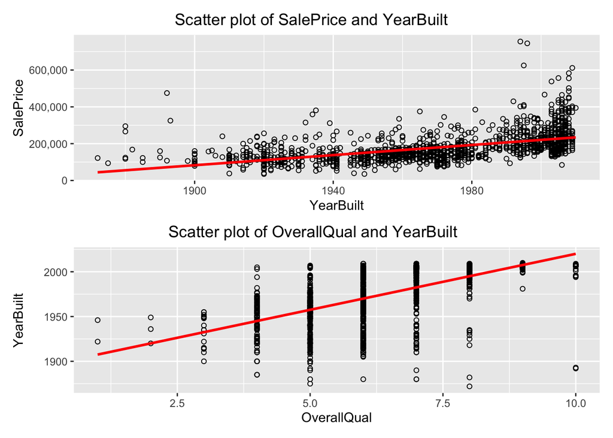

```r
p3 = ggplot(heat, aes(x=YearBuilt, y=SalePrice)) +
  geom_point(shape=1) +
  geom_smooth(method=lm , color="red", se=FALSE)+
  ggtitle("Scatter plot of SalePrice and YearBuilt") +
  theme(plot.title = element_text(hjust = 0.4)) +
  scale_y_continuous(labels = comma)

p4 = ggplot(heat, aes(x=OverallQual, y=YearBuilt)) +
  geom_point(shape=1) +
  geom_smooth(method=lm , color="red", se=FALSE)+
  ggtitle("Scatter plot of OverallQual and YearBuilt") +
  theme(plot.title = element_text(hjust = 0.4))

(p3 / p4)
```

As on above scatter plot, the trend between SalePrice and YearBuilt is raised. The recent house tend to have high sale price. Question is, why? The second scatter plot might give the answer for us. The recent house tend to have higher OverallQual. OverallQual has high correlation with SalePrice. This indicate, that a new house tend to have a high OverallQual which will raised the SalePrice.

# 5. Haunted place(?)

Perhatikan scatter plot berikut

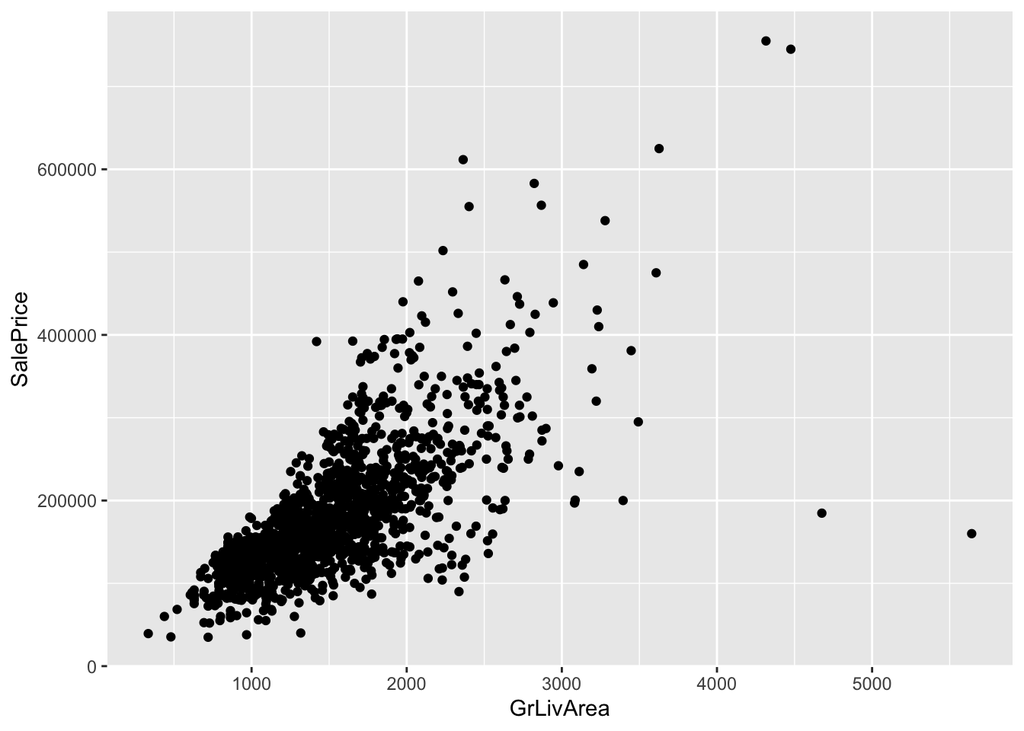

```r
df %>% ggplot(aes(x=GrLivArea,y=SalePrice)) + geom_point()
```

**Question**:

Disebelah kanan, ada dua rumah, yang memiliki GreenLivingArea sangat besar, tetapi SalePrice nya murah. Coba analisis kenapa kedua rumah tersebut murah?

**Answer**:

```r
subset(df, GrLivArea > 4600)
```

```
##      MSSubClass MSZoning LotFrontage LotArea Street Alley LotShape LandContour
## 524          60       RL         130   40094   Pave  <NA>      IR1         Bnk
## 1299         60       RL         313   63887   Pave  <NA>      IR3         Bnk
##      Utilities LotConfig LandSlope Neighborhood Condition1 Condition2 BldgType
## 524     AllPub    Inside       Gtl      Edwards       PosN       PosN     1Fam
## 1299    AllPub    Corner       Gtl      Edwards      Feedr       Norm     1Fam
##      HouseStyle OverallQual OverallCond YearBuilt YearRemodAdd RoofStyle
## 524      2Story          10           5      2007         2008       Hip
## 1299     2Story          10           5      2008         2008       Hip
##      RoofMatl Exterior1st Exterior2nd MasVnrType MasVnrArea ExterQual ExterCond
## 524   CompShg     CemntBd     CmentBd      Stone        762        Ex        TA
## 1299  ClyTile      Stucco      Stucco      Stone        796        Ex        TA
##      Foundation BsmtQual BsmtCond BsmtExposure BsmtFinType1 BsmtFinSF1
## 524       PConc       Ex       TA           Gd          GLQ       2260
## 1299      PConc       Ex       TA           Gd          GLQ       5644
##      BsmtFinType2 BsmtFinSF2 BsmtUnfSF TotalBsmtSF Heating HeatingQC CentralAir
## 524           Unf          0       878        3138    GasA        Ex          Y
## 1299          Unf          0       466        6110    GasA        Ex          Y
##      Electrical X1stFlrSF X2ndFlrSF LowQualFinSF GrLivArea BsmtFullBath
## 524       SBrkr      3138      1538            0      4676            1
## 1299      SBrkr      4692       950            0      5642            2
##      BsmtHalfBath FullBath HalfBath BedroomAbvGr KitchenAbvGr KitchenQual
## 524             0        3        1            3            1          Ex
## 1299            0        2        1            3            1          Ex
##      TotRmsAbvGrd Functional Fireplaces FireplaceQu GarageType GarageYrBlt
## 524            11        Typ          1          Gd    BuiltIn        2007
## 1299           12        Typ          3          Gd     Attchd        2008
##      GarageFinish GarageCars GarageArea GarageQual GarageCond PavedDrive
## 524           Fin          3        884         TA         TA          Y
## 1299          Fin          2       1418         TA         TA          Y
##      WoodDeckSF OpenPorchSF EnclosedPorch X3SsnPorch ScreenPorch PoolArea
## 524         208         406             0          0           0        0
## 1299        214         292             0          0           0      480
##      PoolQC Fence MiscFeature MiscVal MoSold YrSold SaleType SaleCondition
## 524    <NA>  <NA>        <NA>       0     10   2007      New       Partial
## 1299     Gd  <NA>        <NA>       0      1   2008      New       Partial
##      SalePrice
## 524     184750
## 1299    160000
```

Based on above data for those 2 houses, take a look into SaleCondition feature. Both of them have Partial SaleCondition. Partial SaleCondition means the house was not completed when last assessed (associated with New Homes). It means, the price is low because it’s not completed yet.

# 6. Freestyle

Lakukan EDA secara bebas dan sampaikan 1 insight yang sekiranya menarik.